## # **Daily Activity Monitoring**

## Loading and preprocessing the data

```r
library(dplyr)
```

```r
library(ggplot2)
daily.activity <- read.csv("activity.csv")
daily.activity$date <- as.Date(daily.activity$date)
```

## 1 - What is mean total number of steps taken per day?

### 1.1 - Calculate the total number of steps taken per day

```r
total.steps.per.day <- summarise(group_by(daily.activity, date), sumsteps = sum(steps, na.rm = T))
head(total.steps.per.day)
```

```
## # A tibble: 6 x 2
##   date       sumsteps
##   <date>        <int>
## 1 2012-10-01        0
## 2 2012-10-02      126
## 3 2012-10-03    11352
## 4 2012-10-04    12116
## 5 2012-10-05    13294
## 6 2012-10-06    15420
```

### 1.2 - Make a histogram of the total number of steps taken each day

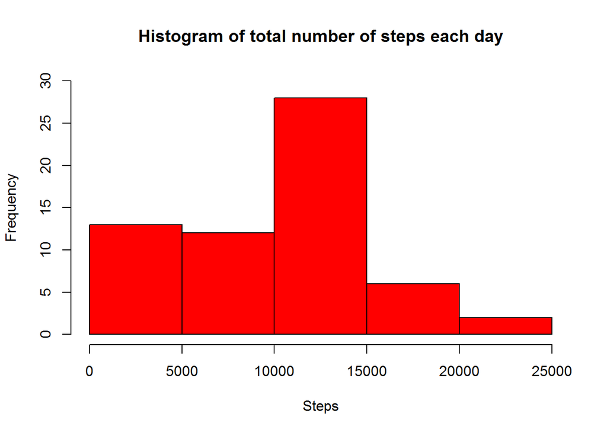

```r
hist(total.steps.per.day$sumsteps, main = "Histogram of total number of steps each day", xlab = "Steps",
     col = "red", ylim = c(0,30))
```

### 1.3 - Calculate and report the MEAN and MEDIAN of the total number of steps taken per day

```r
mean.totalsteps <- round(mean(total.steps.per.day$sumsteps),digits=2)
median.totalsteps <- round(median(total.steps.per.day$sumsteps), digits = 2)
print(paste("Mean :", mean.totalsteps))
```

```
## [1] "Mean : 9354.23"
```

```r
print(paste("Median :", median.totalsteps))
```

```
## [1] "Median : 10395"
```

## 2 - What is the average daily activity pattern?

### 2.1 - Make a time series plot (type=“l”) of the 5-minute interval (x-axis) and the average number of steps taken, averaged across all days (y-axis)

```r
interval.steps <- summarise(group_by(daily.activity, interval),interval.meansteps = mean(steps, na.rm = T))
head(interval.steps)
```

```
## # A tibble: 6 x 2
##   interval interval.meansteps
##      <int>              <dbl>
## 1        0             1.72
## 2        5             0.340
## 3       10             0.132
## 4       15             0.151
## 5       20             0.0755
## 6       25             2.09
```

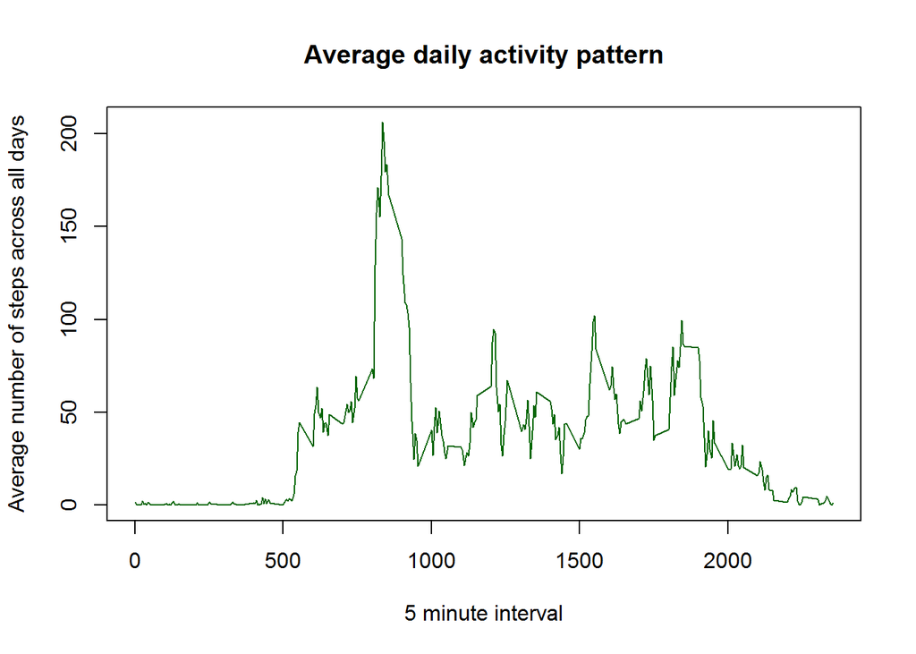

```r
plot(interval.steps$interval, interval.steps$interval.meansteps, xlab = "5 minute interval", col = "dark green",
     ylab = "Average number of steps across all days", main = "Average daily activity pattern", type = "l")
```

### 2.2 - Which 5-minute interval (average across all the days) contains the maximum number of steps?

```r
x1 <- interval.steps$interval[which.max(interval.steps$interval.meansteps)]
x2 <- round(max(interval.steps$interval.meansteps), digits = 2)
print(paste("Interval having max average steps :", x1))
```

```
## [1] "Interval having max average steps : 835"
```

```r
print(paste("The max average steps in that interval :", x2))
```

```
## [1] "The max average steps in that interval : 206.17"
```

## 3 - Imputing missing values

### 3.1 - Calculate total number of missing values in the dataset (i.e. number of rows with NA)

```r
print(paste("The total number of rows with NA :", sum(is.na(daily.activity$steps))))
```

```
## [1] "The total number of rows with NA : 2304"
```

### 3.2 - Create new dataset, equal to the original dataset, but with missing data filled

```r
head(daily.activity)
```

```
##   steps       date interval
## 1    NA 2012-10-01        0
## 2    NA 2012-10-01        5
## 3    NA 2012-10-01       10
## 4    NA 2012-10-01       15
## 5    NA 2012-10-01       20
## 6    NA 2012-10-01       25
```

```r
No.NA.daily.activity <- daily.activity
for (i in 1:nrow(No.NA.daily.activity)) {
      if (is.na(No.NA.daily.activity$steps[i])) {
          j <- i %% 288
          if(j == 0) { j <- 288 }
          No.NA.daily.activity$steps[i] <-  interval.steps$interval.meansteps[j]
      }
}
head(No.NA.daily.activity)
```

```
##       steps       date interval
## 1 1.7169811 2012-10-01        0
## 2 0.3396226 2012-10-01        5
## 3 0.1320755 2012-10-01       10
## 4 0.1509434 2012-10-01       15
## 5 0.0754717 2012-10-01       20
## 6 2.0943396 2012-10-01       25
```

### 3.3 - Make a histogram of the total number of steps taken each day

```r
total.steps.per.day.new <- summarise(group_by(No.NA.daily.activity,date), totalsteps = sum(steps))
head(total.steps.per.day.new)
```

```
## # A tibble: 6 x 2
##   date       totalsteps
##   <date>          <dbl>
## 1 2012-10-01     10766.
## 2 2012-10-02       126
## 3 2012-10-03     11352
## 4 2012-10-04     12116
## 5 2012-10-05     13294
## 6 2012-10-06     15420
```

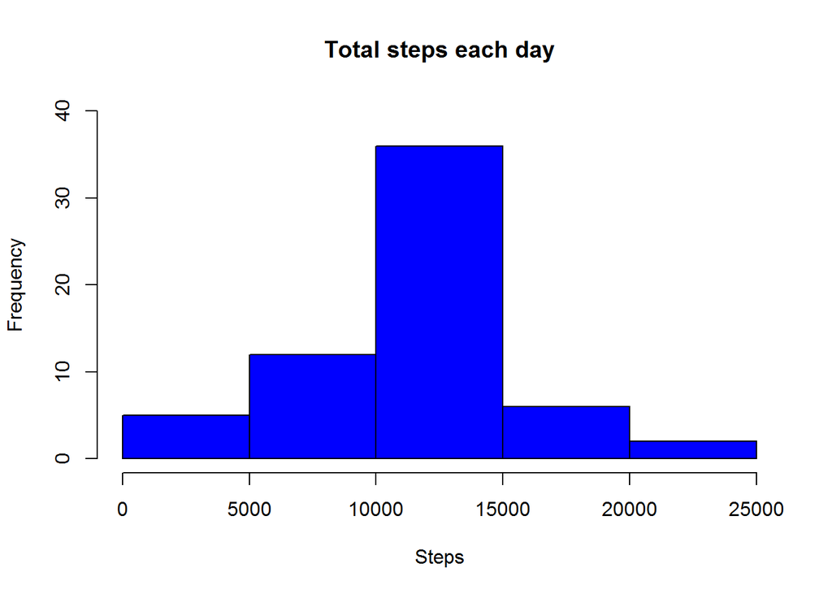

```r
hist(total.steps.per.day.new$totalsteps, xlab = "Steps", main = "Total steps each day", col="blue", ylim=c(0,40))
```

### 3.4 - Calculate MEAN and MEDIAN total number of steps taken per day

```r
x3 <- round(mean(total.steps.per.day.new$totalsteps), digits = 2)
x4 <- round(median(total.steps.per.day.new$totalsteps), digits = 2)
print(paste("New mean :", x3))
```

```
## [1] "New mean : 10766.19"
```

```r
print(paste("New median :", x4))
```

```
## [1] "New median : 10766.19"
```

### 3.5 - Compare with old MEAN and MEDIAN (i.e. before replacing NA values)

```r
Comparison <- data.frame(mean = c(mean.totalsteps,x3), median = c(median.totalsteps,x4))
rownames(Comparison) <- c("Pre NA", "Post NA")
print(Comparison)
```

```
##             mean   median
## Pre NA   9354.23 10395.00
## Post NA 10766.19 10766.19
```

## 4 - Are there differences in activity patterns between WEEKDAYS and WEEKENDS ?

### 4.1 - Create new factor variable in the dataset with two levels – “weekday” and “weekend”

```r
weekdaywise.activity <- No.NA.daily.activity
weekdaywise.activity$date <- as.Date(weekdaywise.activity$date)
weekdaywise.activity$Dayofweek <- weekdays(weekdaywise.activity$date)
weekdaywise.activity$Day <- ifelse(weekdays(weekdaywise.activity$date) %in% c("Saturday","Sunday"),"Weekend","Weekday")
weekdaywise.activity$Day <- as.factor(weekdaywise.activity$Day)
```

### 4.2 - Make a panel plot containing a time series plot (type = “l”) of the 5-minute interval (x-axis) and the average number of steps taken, averaged across all weekday days or weekend days (y-axis)

```r
t1 <- weekdaywise.activity[weekdaywise.activity$Day == "Weekday",c(1,3,5)]
t2 <- weekdaywise.activity[weekdaywise.activity$Day == "Weekend",c(1,3,5)]

t1.1 <- summarise(group_by(t1,interval), average.steps = mean(steps))
t1.1$day <- c("Weekday")
t2.1 <- summarise(group_by(t2,interval), average.steps = mean(steps))
```

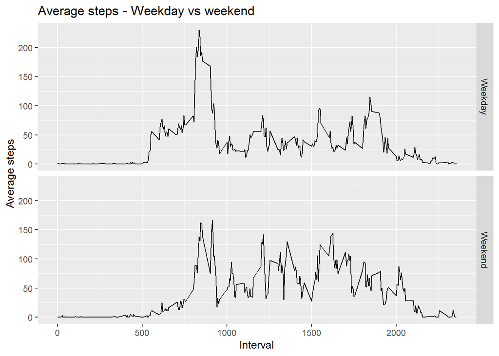

```r
t2.1$day <- c("Weekend")

t3 <- rbind(t1.1,t2.1)
t3$day <- as.factor(t3$day)

g <- ggplot(t3, aes(interval,average.steps))
g + geom_line() + facet_grid(day~.) + xlab("Interval") + ylab("Average steps") +
    ggtitle("Average steps - Weekday vs weekend")
```